# CMM020 MOCK Practical Examination

IA

To take place on 20 March 2024

Clearing the environment.

```r
rm(list=ls())
```

Loading library (package) tidyverse

```r
library(tidyverse)
library(treemapify)
library(igraph)
library(ggraph)
library(ggwordcloud)
```

Loading the data files.

```r
arrivals <- read.csv("arrivals.csv", header=T, stringsAsFactors=T)
numbersPerDay <- read.csv("numbersPerDay.csv", header=T, stringsAsFactors=T)
vessel <- read.csv("vessel.csv", header=T, stringsAsFactors=T)
```

# TASK 1

## Draft

```r
summary(vessel$Draft)
```

```
##    Min. 1st Qu.  Median    Mean 3rd Qu.    Max.
##    3.39    7.45    9.73   10.14   12.48   48.20
```

```r
IQR(vessel$Draft)
```

```
## [1] 5.0325
```

```r
sd(vessel$Draft)
```

```
## [1] 3.201253
```

```r
summary(arrivals$Draft)
```

```
##    Min. 1st Qu.  Median    Mean 3rd Qu.    Max.
##   3.390   6.790   7.890   8.951  11.150  48.200
```

```r
IQR(arrivals$Draft)
```

```
## [1] 4.36
```

```r
sd(arrivals$Draft)
```

```
## [1] 2.966969
```

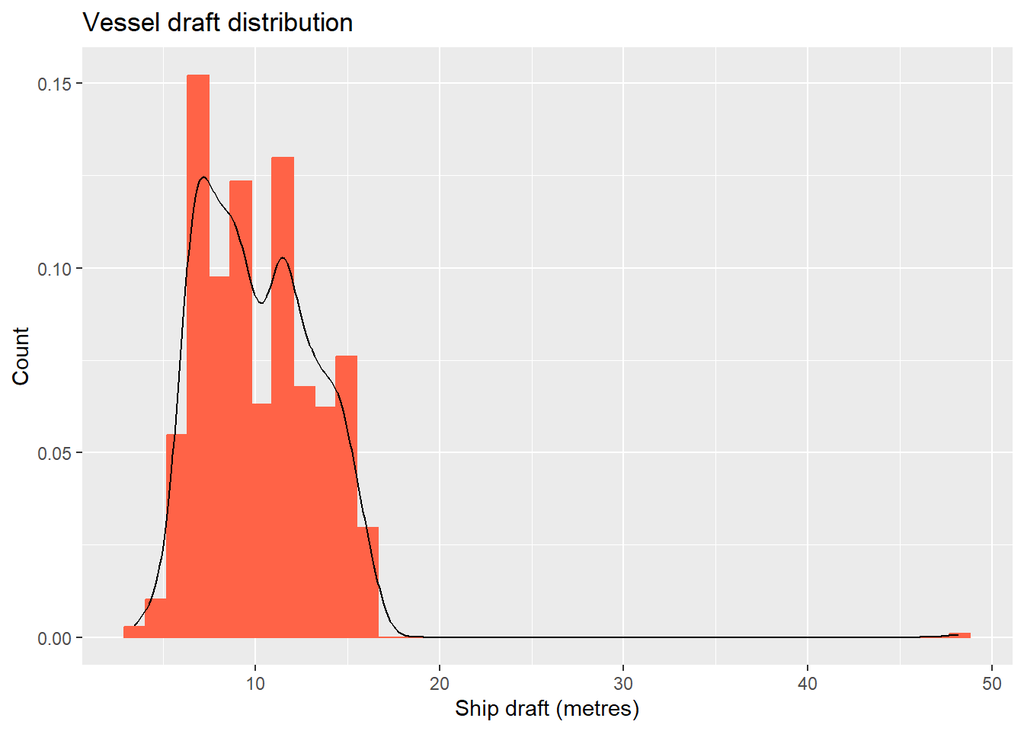

```r
p <- ggplot(vessel, aes(Draft))
p <- p+geom_histogram(colour="tomato", fill="tomato", bins=40 ,aes(y=after_stat(density)) )
p <-  p+geom_density()
p <- p+labs( title="Vessel draft distribution", x = "Ship draft (metres)", y = "Count")
p
```

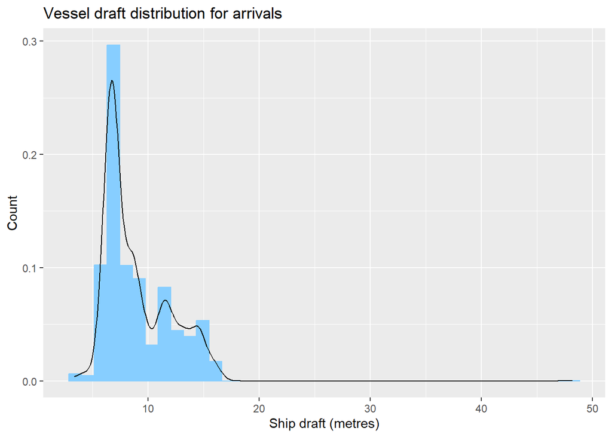

```r
p <- ggplot(arrivals, aes(Draft))
p <- p+geom_histogram(colour="skyblue1", fill="skyblue1", bins=40,  aes(y=after_stat(density)))
p <-  p+geom_density()
p <- p+labs( title="Vessel draft distribution for arrivals", x = "Ship draft (metres)", y = "Count")
p
```

Neither distribution is normal. It can be seen that most individual vessels have a draft of between 5 and 16 metres with a higher frequency between 7 and 12.There are very few vessels with a draft of more than 17, but there are drafts of up to 48 metres.

When looking at arrivals, the most frequent drafts are lower (between 5 and 10 or 12, with a very large peak at around 7 metres). This will be due to the same (small) vessels coming into port more frequently than larger vessels.

## Flag

```r
summary(vessel$Flag)
```

```
##  AG  BM  BS  CY  DE  DK  DZ  ES  FR  GB  HK  IT  LR  LT  MH  MT  NL  NO  PA  PT
##  12   5  25  36  14  36   7  19  11   6  26  84 127   4 117 176  12   9  90  68
##  SG  TN  TR
##  36   3  15
```

```r
summary(arrivals$Flag)
```

```
##  AG  BM  BS  CY  DE  DK  DZ  ES  FR  GB  HK  IT  LR  LT  MH  MT  NL  NO  PA  PT
##  26  11  50 397  35  61  19 173  33  11  37 357 268  24 175 344  16  10 144 134
##  SG  TN  TR
##  48  10  35
```

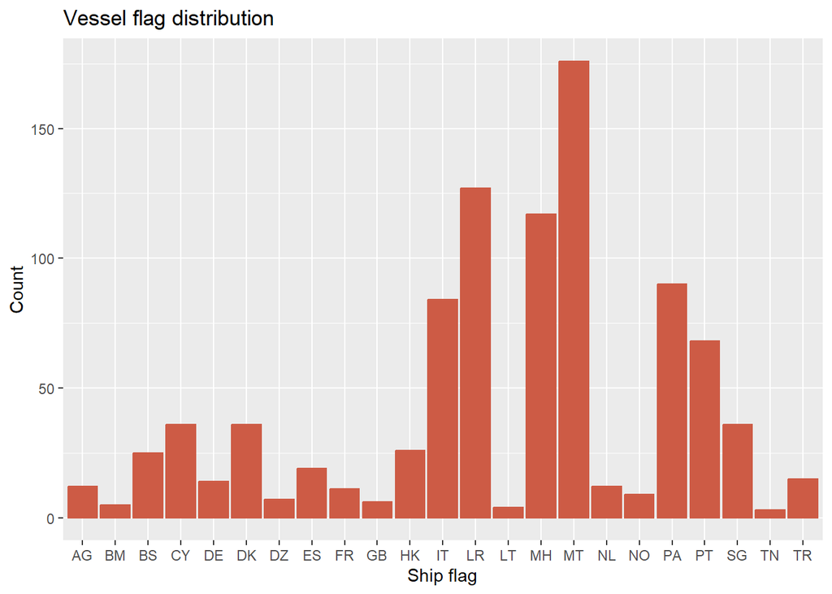

```r
p <- ggplot(vessel, aes(Flag))
p <- p+geom_bar(colour="coral3", fill="coral3")
p <- p+labs( title="Vessel flag distribution", x = "Ship flag", y = "Count")
p
```

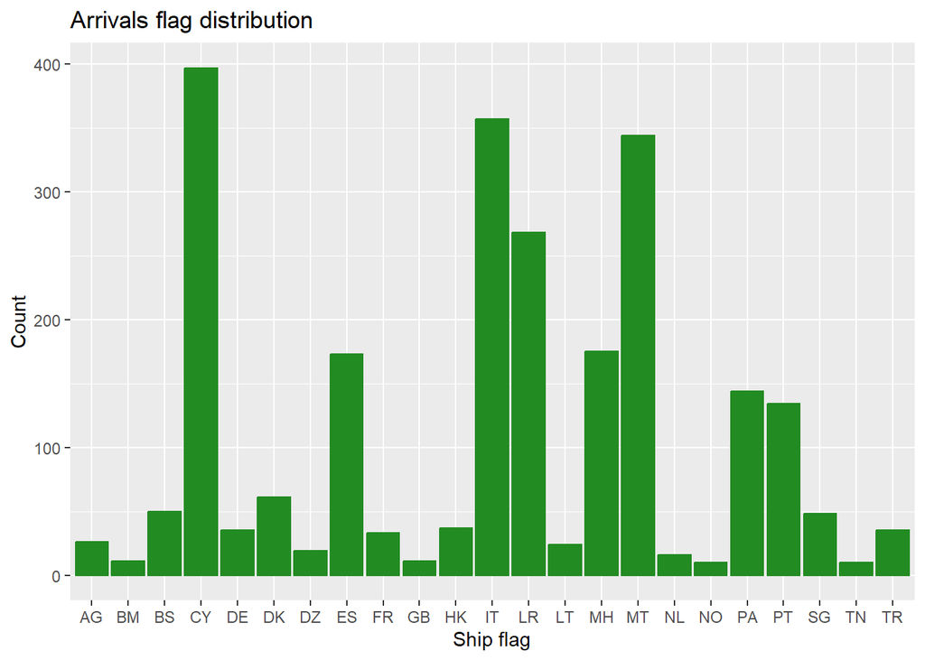

```r
p <- ggplot(arrivals, aes(Flag))
p <- p+geom_bar(colour="forestgreen", fill="forestgreen")
p <- p+labs( title="Arrivals flag distribution", x = "Ship flag", y = "Count")
p
```

A comment regarding the differences in flag distribution is expected, highlighting frequent flags in the vessel distribution when compared to the arrivals distribution. For example the arrival of a vessel with a Cyprus flag is very frequent when compared to other flags, but there are only a few vessels with that flag (with repeated arrivals).

## TASK 2

### Arrivals per day

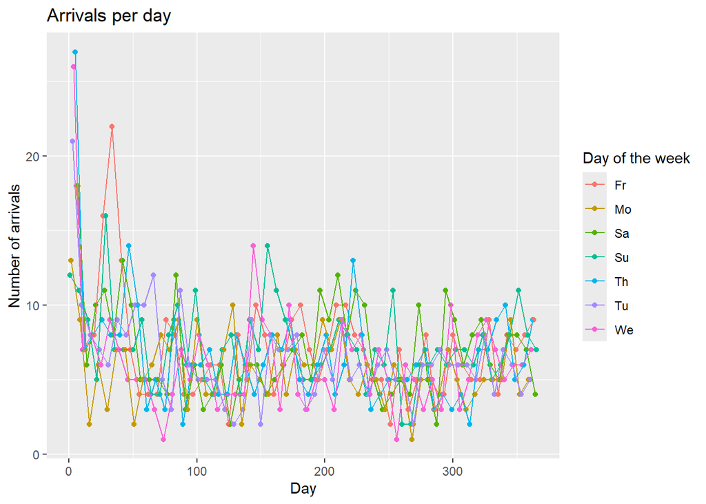

```r
p <- ggplot(numbersPerDay, aes(x=Day, y=ArrivalNumber, colour=DayName))
p <- p+geom_point()
p <- p+geom_line()
p <- p+labs( title="Arrivals per day", x = "Day", y = "Number of arrivals", colour="Day of the week")
p
```

The plot is cluttered and it is difficult to draw conclusions about days of the week. It is clear that there were higher numbers of arrivals for some days during the first 50 days of the year.

### Draft vs beam by type

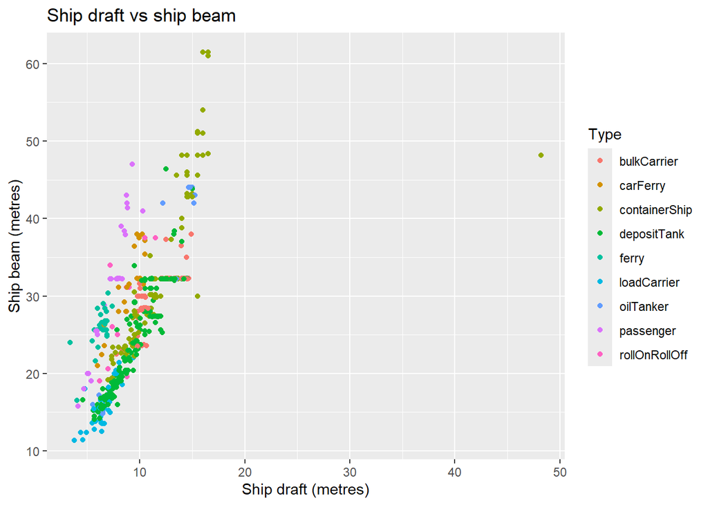

```r
p <- ggplot(vessel, aes(Draft, colour = Type))
p <- p+geom_point(aes(y = Beam))
p <- p+labs( title="Ship draft vs ship beam", x = "Ship draft (metres)", y = "Ship beam (metres)")
p
```

Comments are expected. For example, about the outlier, the smaller vessels and the wide range of sizes of ship beams for similar ship drafts. Container ships seem to vary greatly in draft and beam sizes.